# Baker’s dynamic-effects example

See why one TWFE coefficient need not equal the treated-cell ATT.

The tutorial translates the public simulation in Andrew Baker’s JFE_DID repository. It shows a specific problem: staggered adoption and cohort-specific dynamic effects can make a two-way fixed-effects coefficient differ from a natural average effect.

## 1 Data-generating process

[output not shown]

The untreated outcome is

$$Y_{it}(0)=\alpha_i+\gamma_t+\varepsilon_{it}.$$

For a state in cohort $g$, the effect grows with exposure time:

$$\tau_{it}=s_g(t-g+1), \qquad t\ge g.$$

```python
import matplotlib.pyplot as plt
import numpy as np

from pypanelsim import designs

config = designs.BakerPanelConfig()
panel = designs.baker(config=config, seed=28101695)

print(panel.shape)
print(panel.truth.att_by_cohort())
```

```
(1000, 36)
{'cohort': array([ 9, 18, 27]), 'att': array([1.4  , 0.475, 0.05 ]), 'unit_count': array([353, 357, 290]), 'treated_cell_count': array([9531, 6426, 2610])}
```

The outcome matrix contains the state and year effects, while the treatment matrix shows the three adoption cohorts.

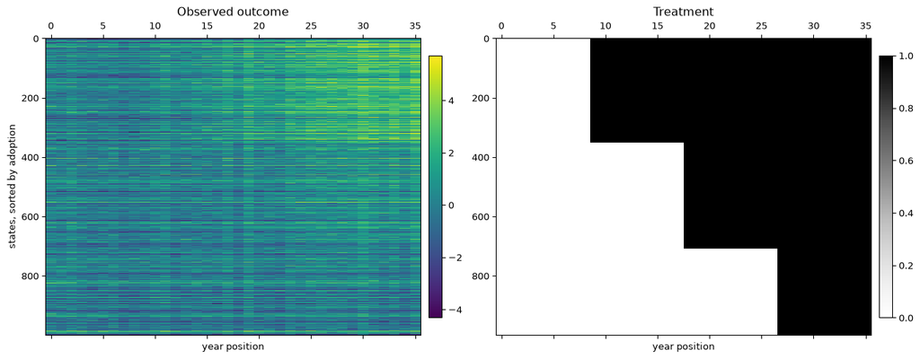

Figure 1: Observed outcomes and staggered treatment in Baker’s dynamic-effects design.

```python
order = np.argsort(panel.adoption_times, kind="stable")
figure, axes = plt.subplots(1, 2, figsize=(13, 5), constrained_layout=True)
outcome_image = axes[0].matshow(
    panel.outcome[order],
    aspect="auto",
    cmap="viridis",
)
treatment_image = axes[1].matshow(
    panel.treatment[order],
    aspect="auto",
    cmap="Greys",
    vmin=0.0,
    vmax=1.0,
)
axes[0].set_title("Observed outcome")
axes[1].set_title("Treatment")
axes[0].set_ylabel("states, sorted by adoption")
for axis in axes:
    axis.set_xlabel("year position")
figure.colorbar(outcome_image, ax=axes[0], fraction=0.035, pad=0.02)
figure.colorbar(treatment_image, ax=axes[1], fraction=0.035, pad=0.02)
plt.show()
```

## 2 The causal target

The treated-cell ATT gives each observed treated cell equal weight:

```python
print("true treated-cell ATT:", round(panel.true_att, 4))
```

```
true treated-cell ATT: 0.8901
```

It is available without fitting an estimator because the simulation stores $Y(0)$ and the realized treatment effect.

## 3 The TWFE coefficient

For a balanced panel, residualize a matrix against unit and time fixed effects by double demeaning:

$$\widetilde Z_{it}
=Z_{it}-\bar Z_{i\cdot}-\bar Z_{\cdot t}+\bar Z_{\cdot\cdot}.$$

The coefficient from $Y_{it}=\alpha_i+\gamma_t+\beta D_{it}+u_{it}$ is then

$$\widehat\beta
=\frac{\sum_{it}\widetilde D_{it}\widetilde Y_{it}}
{\sum_{it}\widetilde D_{it}^2}.$$

```python
def double_demean(values):
    return (
        values
        - values.mean(axis=1, keepdims=True)
        - values.mean(axis=0, keepdims=True)
        + values.mean()
    )

d_tilde = double_demean(panel.treatment)
y_tilde = double_demean(panel.outcome)
twfe = float(np.sum(d_tilde * y_tilde) / np.sum(d_tilde**2))

print("TWFE coefficient:", round(twfe, 4))
print("true treated-cell ATT:", round(panel.true_att, 4))
print("difference:", round(twfe - panel.true_att, 4))
```

```
TWFE coefficient: -0.2034
true treated-cell ATT: 0.8901
difference: -1.0935
```

The difference is not a software error. The regression coefficient weights cells by residualized treatment. With staggered adoption, already-treated cohorts can act as comparisons for later cohorts. Dynamic and cohort-varying effects then enter with weights that do not match treated-cell ATT weights.

## 4 Inspect cohort-event effects

```python
cohort_truth = panel.truth.cohort_event(event_times=range(0, 8))

for cohort in np.unique(cohort_truth["cohort"]):
    selected = cohort_truth["cohort"] == cohort
    effects = cohort_truth["effect"][selected]
    print(int(cohort), np.round(effects, 2))
```

```
9 [0.1 0.2 0.3 0.4 0.5 0.6 0.7 0.8]
18 [0.05 0.1  0.15 0.2  0.25 0.3  0.35 0.4 ]
27 [0.01 0.02 0.03 0.04 0.05 0.06 0.07 0.08]
```

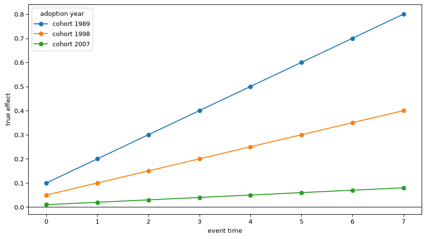

Figure 2: True treatment-effect paths by adoption cohort.

```python
figure, axis = plt.subplots(figsize=(9, 5), constrained_layout=True)
for cohort in np.unique(cohort_truth["cohort"]):
    selected = cohort_truth["cohort"] == cohort
    axis.plot(
        cohort_truth["event_time"][selected],
        cohort_truth["effect"][selected],
        marker="o",
        label=f"cohort {config.start_year + int(cohort)}",
    )
axis.axhline(0.0, color="black", linewidth=0.8)
axis.set_xlabel("event time")
axis.set_ylabel("true effect")
axis.legend(title="adoption year")
plt.show()
```

The early cohort has both the steepest slope and the longest observed exposure. That combination makes the mismatch visible.

## 5 Isolate design from noise

Set `noise_scale=0` to remove sampling noise while keeping the same assignment and effect structure:

```python
noiseless = designs.BakerPanelConfig(n_units=200, noise_scale=0.0)
noiseless_panel = designs.baker(config=noiseless, seed=42)

d_tilde = double_demean(noiseless_panel.treatment)
y_tilde = double_demean(noiseless_panel.outcome)
noiseless_twfe = float(np.sum(d_tilde * y_tilde) / np.sum(d_tilde**2))

print("noiseless TWFE:", round(noiseless_twfe, 4))
print("noiseless ATT:", round(noiseless_panel.true_att, 4))
```

```
noiseless TWFE: -0.2213
noiseless ATT: 0.9363
```

If the gap remains without noise, it comes from the estimand and design rather than sampling variation.

## 6 What this design does not prove

One simulation does not show that TWFE always fails. It shows a case where its coefficient and a common ATT target differ. Change effect slopes, cohort sizes, timing, and noise across replications before making a performance claim about an estimator.